# Q-3 Project Summary - Sentiment Analysis with Custom Transformer Model & DistilBERT

| Contributor | Contributions |
| --- | --- |
| **Urjeet Parmar** | - Implemented **Custom Transformer Model (Model V1)** with hyperparameter tuning. |
|  | - **Preprocessed dataset** (cleaning text, tokenization, label mapping). |
|  | - Handled **data leakage** and ensured proper train-test split. |
|  | - **Balanced dataset** using class weighting for training stability. |
|  | - **Evaluated Model V1** using Accuracy, F1-score, Confusion Matrix, and AUC-ROC. |
|  | - **Visualized key insights** (Class distribution, Text length, Wordcloud, Hashtag usage). |
|  | - **Interpreted Model V1 predictions** with **LIME explanations** for feature importance. |
|  | - **Compared global and local feature importance** for Model V1. |

| Contributor | Contributions |
| --- | --- |
| **Devendra Singh Shekhawat** | - Implemented **Custom Transformer Model (Model V2)** with optimized hyperparameters. |
|  | - **Trained and fine-tuned DistilBERT** for sentiment classification. |
|  | - **Optimized dataset** by improving tokenization and encoding efficiency. |
|  | - **Trained and evaluated Model V2 & DistilBERT**, improving generalization. |
|  | - **Compared Model V2 vs DistilBERT** on sentiment classification performance. |
|  | - **Evaluated Model V2 & DistilBERT** using Accuracy, F1-score, Confusion Matrix, and AUC-ROC. |
|  | - **Interpreted Model V2 & DistilBERT predictions** using LIME for local/global feature importance. |

### Summary:

This project focused on **sentiment analysis** using both **custom transformer architectures** (relative positional encoding) and **pretrained DistilBERT**. The team iteratively improved **model accuracy, feature importance insights, and interpretability** through **data preprocessing, hyperparameter tuning, and evaluation metrics** to determine the best model for sentiment classification.

# Project Evaluation Table

| Task | Status | Results |
| --- | --- | --- |
| **Data Preprocessing & Cleaning** | Text cleaning, removing URLs, mentions, emojis, contractions | Processed dataset ready for training |
| **Data Splitting & Leakage Check** | Train-test split performed, checked for overlap | No data leakage confirmed |
| **Sentiment Label Mapping** | Labels mapped correctly | Mapping validated |
| **Exploratory Data Analysis (EDA)** | Sentiment distribution, text length distribution, frequent words, hashtags analyzed | Insights derived from visualizations |
| **Feature Engineering** | Tokenization applied using DistilBERT | Tokenized dataset prepared for training |
| **Class Balancing** | Applied class weights for handling imbalance | Optimized class distribution for training |
| **Model Training - Custom Causal Transformer (v1, v2)** | Trained with hyperparameter tuning | Best hyperparameters identified |
| **Model Training - DistilBERT** | Fine-tuned on dataset | Model trained successfully |
| **Evaluation Metrics Computed** | Accuracy, F1-score, Precision, Recall, Confusion Matrix, AUC-ROC | Model performance analyzed |

### **Model Performance Scores**

#### **Causal Transformer (Model_v1)**

- **Train Accuracy:** 77.82%
- **Test Accuracy:** 64.61%
- **Macro F1-score:** 52.43%
- **Weighted F1-score:** 65.47%
- **AUC-ROC (Micro-average):** 0.89

#### **Causal Transformer (Model_v2)**

- **Train Accuracy:** 72.28%
- **test Accuracy:** 63.08%
- **Macro F1-score:** 51.06%
- **Weighted F1-score:** 64.21%
- **AUC-ROC (Micro-average):** 0.88

#### **DistilBERT**

- **Test Accuracy:** 72.28%
- **Macro F1-score:** 53.86%
- **Weighted F1-score:** 67.55%
- **AUC-ROC (Micro-average):** 0.91

| **Model** | **Accuracy** | **Macro F1** | **Weighted F1** | **AUC-ROC (Micro)** |
| --- | --- | --- | --- | --- |
| Causal Transformer (v1) | 64.61% | 52.43% | 65.47% | 0.89 |
| Causal Transformer (v2) | 63.08% | 51.06% | 64.21% | 0.88 |
| DistilBERT | **72.28%** | **53.86%** | **67.55%** | **0.91** |

### **Model Interpretability - LIME**

| **Model** | **Most Important Words** |
| --- | --- |
| Causal Transformer (v1) | Great, love, I, my, was, special, okay |
| Causal Transformer (v2) | Great, love, recommend, exceeded, product, know |
| DistilBERT | Excellent, service, satisfied, worst, amazing, terrible |

### **Model Comparison - Causal Transformer vs DistilBERT**

| **Evaluation Metric** | **Model_v1** | **Model_v2** | **DistilBERT** |
| --- | --- | --- | --- |
| Accuracy | 64.61% | 63.08% | **72.28%** |
| F1-score (Macro) | 52.43% | 51.06% | **53.86%** |
| F1-score (Weighted) | 65.47% | 64.21% | **67.55%** |
| AUC-ROC (Micro) | 0.89 | 0.88 | **0.91** |

### **Final Model Selection**

- **DistilBERT** outperformed the Causal Transformer models in all metrics.
- **Better accuracy (72.28%) and AUC-ROC (0.91)** make it the most reliable choice.
- **Recommended for deployment.**

# Step-1.Importing Libraries

```python
import os
import time
import random
import unicodedata
import re
import numpy as np
import pandas as pd
import torch
import torch.nn as nn
import torch.optim as optim
import torch.nn.functional as F
import matplotlib.pyplot as plt
import seaborn as sns
from collections import Counter, defaultdict
from bs4 import BeautifulSoup
from wordcloud import WordCloud
from sklearn.model_selection import train_test_split
from sklearn.metrics import (
    classification_report,
    confusion_matrix,
    accuracy_score,
    f1_score,
    roc_curve,
    auc
)
from sklearn.preprocessing import label_binarize
from torch.utils.data import DataLoader, Dataset, TensorDataset
from transformers import (
    AutoTokenizer,
    DistilBertTokenizer,
    DistilBertModel
)
from lime.lime_text import LimeTextExplainer
```

# Let's Check if notebook utlizies my gpu

```python
print("Is CUDA available? ", torch.cuda.is_available())
print("CUDA device count: ", torch.cuda.device_count())
print("Current CUDA device: ", torch.cuda.current_device())
if torch.cuda.is_available():
    print("CUDA device name: ", torch.cuda.get_device_name(0))
```

```
Is CUDA available?  True
CUDA device count:  1
Current CUDA device:  0
CUDA device name:  NVIDIA GeForce RTX 3050 Laptop GPU
```

```python
#Force PyTorch to use RTX 3050
os.environ["CUDA_VISIBLE_DEVICES"] = "0"  # Change "0" if RTX 3050 is on another GPU index

# Select RTX 3050 manually
device = torch.device("cuda:0" if torch.cuda.is_available() else "cpu")

# Confirm the selected GPU
if torch.cuda.is_available():
    print(f" Using device: {device} ({torch.cuda.get_device_name(device.index)})")
else:
    print(" CUDA is not available. Running on CPU.")
```

```
d:\Casual Transformer\deep_env\Lib\site-packages\tqdm\auto.py:21: TqdmWarning: IProgress not found. Please update jupyter and ipywidgets. See https://ipywidgets.readthedocs.io/en/stable/user_install.html
  from .autonotebook import tqdm as notebook_tqdm
```

```
 Using device: cuda:0 (NVIDIA GeForce RTX 3050 Laptop GPU)
```

```python
file_path = "Sentiment_Data_60k.csv"

# Try reading the file with different encodings
try:
    df = pd.read_csv(file_path, encoding='utf-8')
except UnicodeDecodeError:
    try:
        df = pd.read_csv(file_path, encoding='latin1')
    except UnicodeDecodeError:
        df = pd.read_csv(file_path, encoding='iso-8859-1')
print(df.head())
```

```
                                               Tweet Sentiment
0  @_angelica_toy Happy Anniversary!!!....The Day...  Mild_Pos
1  @McfarlaneGlenda Happy Anniversary!!!....The D...  Mild_Pos
2  @thevivafrei @JustinTrudeau Happy Anniversary!...  Mild_Pos
3  @NChartierET Happy Anniversary!!!....The Day t...  Mild_Pos
4  @tabithapeters05 Happy Anniversary!!!....The D...  Mild_Pos
```

# Step-2 Data Preprocessing

```python
#  Advanced Text Cleaning Function
def clean_text(text):
    """Cleans text (removes HTML, URLs, mentions, expands contractions, normalizes Unicode, converts emojis)."""
    if pd.isna(text):
        return ""

    text = BeautifulSoup(text, "html.parser").get_text()
    text = re.sub(r"http\S+|www.\S+", "", text)  # Remove URLs
    text = re.sub(r"@\w+", "", text)  # Remove Mentions

    # Expand contractions
    contractions = {"can't": "cannot", "won't": "will not", "n't": " not", "it's": "it is", "i'm": "i am",
                    "you're": "you are", "he's": "he is", "she's": "she is", "they're": "they are"}
    for contraction, expansion in contractions.items():
        text = text.replace(contraction, expansion)

    # Normalize Unicode characters (e.g., café → cafe)
    text = unicodedata.normalize("NFKD", text).encode("ascii", "ignore").decode("utf-8")

    # Convert emojis to text
    text = emoji.demojize(text, delimiters=(" ", " "))

    # Remove punctuation except hashtags
    text = re.sub(r"[^\w\s#]", "", text)

    return text.strip()

#  Apply text cleaning
df["Cleaned_Tweet"] = df["Tweet"].apply(clean_text)

#  Remove duplicates to prevent data leakage
df = df.drop_duplicates(subset=["Cleaned_Tweet"]).reset_index(drop=True)

#  Load tokenizer
tokenizer = AutoTokenizer.from_pretrained("distilbert-base-uncased")

#  Step 1: Split data BEFORE tokenization (Ensuring No Data Leakage)
train_df, test_df = train_test_split(df, test_size=0.2, random_state=42, stratify=df["Sentiment"])

#  Step 2: Ensure No Data Leakage (Check Overlapping Samples)
train_set = set(train_df["Cleaned_Tweet"])
test_set = set(test_df["Cleaned_Tweet"])
leaked_samples = train_set.intersection(test_set)

if len(leaked_samples) > 0:
    print(f"⚠️ Data Leakage Detected! {len(leaked_samples)} samples exist in both train & test sets. Removing them.")
    train_df = train_df[~train_df["Cleaned_Tweet"].isin(leaked_samples)]
    test_df = test_df[~test_df["Cleaned_Tweet"].isin(leaked_samples)]

#  Step 3: Apply Tokenization & Encoding
def tokenize_tweet(text):
    return tokenizer.encode(text, padding="max_length", truncation=True, max_length=128)

train_df["Tokenized_Tweet"] = train_df["Cleaned_Tweet"].apply(tokenize_tweet)
test_df["Tokenized_Tweet"] = test_df["Cleaned_Tweet"].apply(tokenize_tweet)

if "Tokenized_Tweet" in train_df.columns and "Tokenized_Tweet" in test_df.columns:
    print("✅ Tokenized_Tweet column successfully created.")
else:
    print("❌ Tokenized_Tweet column is missing. Check preprocessing pipeline.")

#  Step 4: Ensure Correct Sentiment Label Mapping
unique_sentiments = df["Sentiment"].unique()

# Manually create correct mapping (Ensure alignment)
sentiment_mapping = {sentiment: idx for idx, sentiment in enumerate(unique_sentiments)}

#  Apply Mapping
train_df["Sentiment_Label"] = train_df["Sentiment"].map(sentiment_mapping)
test_df["Sentiment_Label"] = test_df["Sentiment"].map(sentiment_mapping)

#  Display Mapping for Debugging
print("\n Sentiment Mapping:")
for label, idx in sentiment_mapping.items():
    print(f"  {label} → {idx}")

#  Step 5: Move Data to CUDA for Faster Processing
train_texts = torch.tensor(train_df["Tokenized_Tweet"].tolist(), dtype=torch.long).to(device)
train_labels = torch.tensor(train_df["Sentiment_Label"].tolist(), dtype=torch.long).to(device)
test_texts = torch.tensor(test_df["Tokenized_Tweet"].tolist(), dtype=torch.long).to(device)
test_labels = torch.tensor(test_df["Sentiment_Label"].tolist(), dtype=torch.long).to(device)

print("\n Data Preprocessing Completed & Ready for Model Training!")
```

```
✅ Tokenized_Tweet column successfully created.

🗂️ Sentiment Mapping:
  Mild_Pos → 0
  Strong_Pos → 1
  Neutral → 2
  Strong_Neg → 3
  Mild_Neg → 4

✅ Data Preprocessing Completed & Ready for Model Training!
```

```python
print(train_df[["Cleaned_Tweet", "Tokenized_Tweet"]].head())
```

```
                                           Cleaned_Tweet  \
31718  Ohmygosh hilarious \nWish the toy truck was re...
43101  622 The Freedom Convoy created lots of problem...
8129   Yet the president is going to come across Cana...
26934  You need to look at china That is what the fre...
27832  Great\n\nYou might get more than you bargained...

                                         Tokenized_Tweet
31718  [101, 2821, 8029, 12333, 2232, 26316, 4299, 19...
43101  [101, 5786, 2475, 1996, 4071, 9549, 2580, 7167...
8129   [101, 2664, 1996, 2343, 2003, 2183, 2000, 2272...
26934  [101, 2017, 2342, 2000, 2298, 2012, 2859, 2008...
27832  [101, 2307, 2017, 2453, 2131, 2062, 2084, 2017...
```

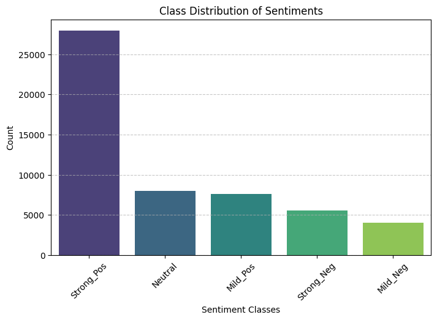

```python
# 1️ Class Distribution
plt.figure(figsize=(8, 5))
sns.countplot(x=df["Sentiment"], order=df["Sentiment"].value_counts().index, palette="viridis")
plt.title("Class Distribution of Sentiments")
plt.xlabel("Sentiment Classes")
plt.ylabel("Count")
plt.xticks(rotation=45)
plt.grid(axis='y', linestyle='--', alpha=0.7)
plt.show()
```

### Insights from Sentiment Distribution:

- **Strong_Pos is the most common sentiment**, meaning the dataset is imbalanced.
- **Neutral and Mild_Pos have similar counts**, making them relatively balanced.
- **Negative sentiments (Strong_Neg, Mild_Neg) are the least frequent**, which might make the model struggle to predict them.
- **The model could be biased toward Strong_Pos**, since it's the dominant class.
- **Might need resampling or weighted loss** to ensure fair predictions.

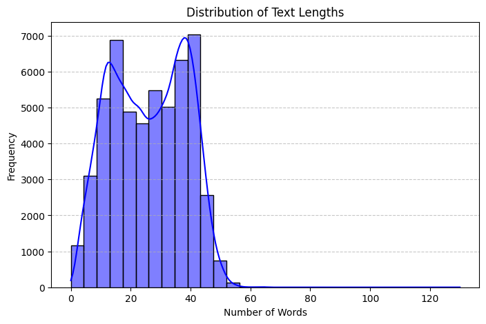

```python
# 2️ Text Length Distribution
df["Text_Length"] = df["Cleaned_Tweet"].apply(lambda x: len(x.split()))
plt.figure(figsize=(8, 5))
sns.histplot(df["Text_Length"], bins=30, kde=True, color="blue")
plt.title("Distribution of Text Lengths")
plt.xlabel("Number of Words")
plt.ylabel("Frequency")
plt.grid(axis='y', linestyle='--', alpha=0.7)
plt.show()
```

### Simple Takeaways from Text Length Distribution:

- Most texts are **10 to 40 words long**.
- There are **two common text lengths**, around **15 and 40 words**.
- Very **few texts are longer than 50 words**.
- **Short texts might need padding**, and **longer ones may hold more details**.
- Keeping a **max length of 128 tokens** seems safe.

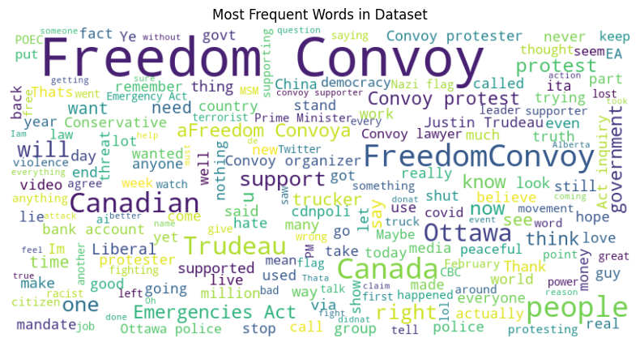

```python
# 3️ Word Cloud for Most Frequent Words
all_words = " ".join(df["Cleaned_Tweet"])
wordcloud = WordCloud(width=800, height=400, background_color="white").generate(all_words)

plt.figure(figsize=(10, 5))
plt.imshow(wordcloud, interpolation="bilinear")
plt.axis("off")
plt.title("Most Frequent Words in Dataset")
plt.show()
```

### Key Insights from the Word Cloud:

- **"Freedom" and "Convoy"** are the most frequently used words, suggesting a strong focus on **protests**.
- Other common words like **"Trudeau," "Canada," and "Ottawa"** indicate discussions related to **government and policies**.
- Terms like **"protest," "support," and "people"** suggest public involvement and sentiment.
- Words like **"Emergencies Act" and "government"** highlight political and legal aspects.
- Overall, the dataset seems **heavily centered around a political movement**.

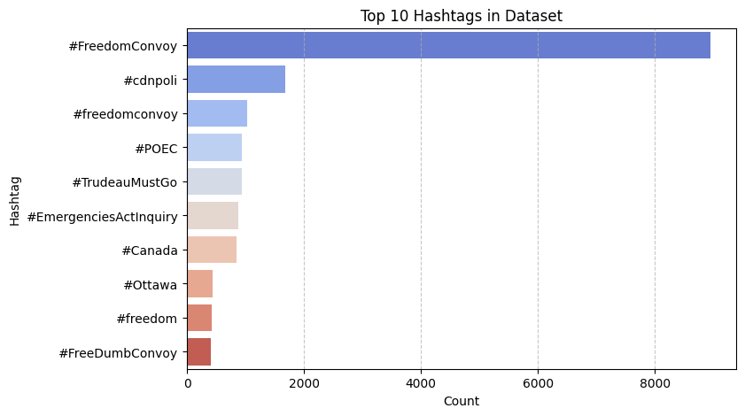

```
❌ Tokenized_Tweet column is still missing. Check preprocessing.
```

```python
# 4️ Top Hashtags
hashtags = [word for tweet in df["Cleaned_Tweet"] for word in tweet.split() if word.startswith("#")]
top_hashtags = pd.Series(hashtags).value_counts().head(10)

plt.figure(figsize=(8, 5))
sns.barplot(x=top_hashtags.values, y=top_hashtags.index, palette="coolwarm")
plt.title("Top 10 Hashtags in Dataset")
plt.xlabel("Count")
plt.ylabel("Hashtag")
plt.grid(axis='x', linestyle='--', alpha=0.7)
plt.show()

if "Tokenized_Tweet" in df.columns:
    train_df["Token_Length"] = train_df["Tokenized_Tweet"].apply(lambda x: len(x) if isinstance(x, list) else 0)

    plt.figure(figsize=(8, 5))
    sns.histplot(df["Token_Length"], bins=30, kde=True, color="green")
    plt.title("Distribution of Tokenized Text Lengths")
    plt.xlabel("Number of Tokens")
    plt.ylabel("Frequency")
    plt.grid(axis='y', linestyle='--', alpha=0.7)
    plt.show()
else:
    print("❌ Tokenized_Tweet column is still missing. Check preprocessing.")
```

### Key Insights from the Hashtag Analysis:

- **#FreedomConvoy** is the most dominant hashtag, appearing significantly more than others.
- Other frequently used hashtags like **#cdnpoli, #POEC, and #EmergenciesActInquiry** suggest discussions around **Canadian politics and policies**.
- **#TrudeauMustGo** indicates opposition towards the Prime Minister, reflecting strong political opinions.
- **#Ottawa and #Canada** suggest that the movement has a national focus.
- The presence of **#FreeDumbConvoy** indicates **counter-narratives and criticism** within the dataset.

```python
# Compute class counts
class_counts = Counter(train_df["Sentiment_Label"])
total_samples = sum(class_counts.values())

# Compute class weights (normalized and memory-efficient)
class_weights = torch.tensor(
    [total_samples / class_counts[i] for i in sorted(class_counts.keys())],
    dtype=torch.float32
).to(device)

print("Class Weights (Optimized):", class_weights)
```

```
Class Weights (Optimized): tensor([ 7.0023,  1.9004,  6.6537,  9.5628, 13.1366], device='cuda:0')
```

```python
def weighted_loss_function(outputs, labels):
    """
    Computes cross-entropy loss with class weighting.
    """
    return F.cross_entropy(outputs, labels, weight=class_weights)
```

[figure not shown]

```python
# Plot the weight distribution
plt.figure(figsize=(8, 5))
sns.barplot(x=list(class_counts.keys()), y=class_weights.cpu().numpy(), palette="coolwarm")
plt.title("Optimized Class Weights for Training")
plt.xlabel("Sentiment Classes")
plt.ylabel("Weight")
plt.xticks(rotation=45)
plt.grid(axis='y', linestyle='--', alpha=0.7)
plt.show()
```

# Initialize Transformer model with relative positions

```python
class TransformerBlock(nn.Module):
    def __init__(self, embed_dim, num_heads, ff_dim, dropout=0.1):
        super().__init__()
        self.attn = nn.MultiheadAttention(embed_dim, num_heads, dropout=dropout, batch_first=True)
        self.norm1 = nn.LayerNorm(embed_dim)
        self.ff = nn.Sequential(
            nn.Linear(embed_dim, ff_dim),
            nn.GELU(),
            nn.Linear(ff_dim, embed_dim),
            nn.Dropout(dropout)
        )
        self.norm2 = nn.LayerNorm(embed_dim)
        self.dropout = nn.Dropout(dropout)

    def forward(self, x, attn_mask=None):
        attn_output, _ = self.attn(x, x, x, attn_mask=attn_mask, need_weights=False)
        x = self.norm1(x + self.dropout(attn_output))
        ff_output = self.ff(x)
        x = self.norm2(x + self.dropout(ff_output))
        return x

class CausalTransformer(nn.Module):
    def __init__(self, vocab_size, embed_dim, num_heads, num_layers, ff_dim, max_seq_len, num_classes, max_relative_position=10, dropout=0.1):
        super().__init__()
        self.token_embedding = nn.Embedding(vocab_size, embed_dim)
        self.max_relative_position = int(max_relative_position)  #  Ensure integer type
        self.relative_bias = nn.Parameter(torch.zeros(2 * self.max_relative_position + 1, num_heads))  #  Fixed
        self.layers = nn.ModuleList([
            TransformerBlock(embed_dim, num_heads, ff_dim, dropout)
            for _ in range(num_layers)
        ])
        self.ln_f = nn.LayerNorm(embed_dim)
        self.fc_out = nn.Linear(embed_dim, num_classes)

    def forward(self, x, key_padding_mask=None):
        N, S = x.shape
        device = x.device

        # Compute relative position indices
        positions = torch.arange(S, device=device).unsqueeze(0) - torch.arange(S, device=device).unsqueeze(1)
        clipped_positions = positions.clamp(-self.max_relative_position, self.max_relative_position)
        rel_indices = clipped_positions + self.max_relative_position
        # Reshape bias_matrix to match (S, S, 1)
        bias_matrix = self.relative_bias[rel_indices]  # Shape: (S, S, num_heads)
        bias_matrix = bias_matrix.permute(2, 0, 1)  # Change to (num_heads, S, S)
        bias_matrix = bias_matrix.mean(dim=0)  # Average over heads, final shape (S, S)

        # Create causal mask (S, S)
        causal_mask = torch.tril(torch.ones((S, S), device=device)).bool()

        # Combine causal mask with bias
        attn_mask = torch.where(causal_mask, bias_matrix, torch.tensor(-1e9, device=device))

        # Embed tokens
        x = self.token_embedding(x)

        # Pass through transformer layers
        for layer in self.layers:
            x = layer(x, attn_mask=attn_mask)

        x = self.ln_f(x)
        last_token_output = x[:, -1, :]
        return self.fc_out(last_token_output)

print(" Causal Transformer with Relative Position Encoding Initialized!")
```

```
 Causal Transformer with Relative Position Encoding Initialized!
```

```python
# Convert tokenized tweets to PyTorch tensors
train_texts_balanced = torch.tensor(train_texts.tolist(), dtype=torch.long).to(device)
train_labels_balanced = torch.tensor(train_labels.tolist(), dtype=torch.long).to(device)
test_texts = torch.tensor(test_texts.tolist(), dtype=torch.long).to(device)
test_labels = torch.tensor(test_labels.tolist(), dtype=torch.long).to(device)

# Create DataLoader for efficient batch processing
BATCH_SIZE = 64

train_dataset = TensorDataset(train_texts_balanced, train_labels_balanced)
train_loader = DataLoader(train_dataset, batch_size=BATCH_SIZE, shuffle=True)

test_dataset = TensorDataset(test_texts, test_labels)
test_loader = DataLoader(test_dataset, batch_size=BATCH_SIZE, shuffle=False)

print(" Data Prepared - Ready for Training")
```

```
✅ Data Prepared - Ready for Training
```

## Tried to run the model by changing params multiple time

```python
# Define optimized model hyperparameters
VOCAB_SIZE = 30522  # Standard BERT vocabulary size (unchanged)
EMBED_DIM = 256     # Increased from 128 to 256 for richer embeddings
NUM_HEADS = 8       # Increased from 4 to 8 for better attention
NUM_LAYERS = 4      # Kept at 4 (reasonable for Twitter data)
FF_DIM = 1024       # Increased from 512 to 1024 for complex patterns
MAX_SEQ_LEN = 64    # Reduced from 128 to 64 for shorter Twitter text
NUM_CLASSES = len(torch.unique(train_labels_balanced))  # Unchanged (e.g., 3 for sentiment)
DROPOUT = 0.2       # Increased from 0.1 to 0.2 to reduce overfitting

# Initialize model
device = torch.device("cuda" if torch.cuda.is_available() else "cpu")
model = CausalTransformer(VOCAB_SIZE, EMBED_DIM, NUM_HEADS, NUM_LAYERS, FF_DIM, MAX_SEQ_LEN, NUM_CLASSES, DROPOUT).to(device)

# Define optimizer and learning rate scheduler
optimizer = optim.AdamW(model.parameters(), lr=5e-5, weight_decay=1e-2)  # Adjusted lr and weight decay
scheduler = optim.lr_scheduler.CosineAnnealingLR(optimizer, T_max=10)    # Switched to cosine scheduler

# Loss function with class weights (handling imbalance)
criterion = nn.CrossEntropyLoss(weight=class_weights)

print(" Optimized Model & Training Setup Complete")
```

```
✅ Optimized Model & Training Setup Complete
```

```python
EPOCHS = 10
PATIENCE = 3  # Stop training if validation loss doesn't improve for 3 epochs

best_val_loss = float("inf")
epochs_no_improve = 0

for epoch in range(EPOCHS):
    start_time = time.time()
    model.train()

    total_loss = 0
    correct = 0
    total = 0

    for batch in train_loader:
        texts, labels = batch
        texts, labels = texts.to(device), labels.to(device)

        optimizer.zero_grad()
        outputs = model(texts)

        #  Apply Softmax before argmax
        probs = torch.softmax(outputs, dim=1)
        preds = torch.argmax(probs, dim=1)

        loss = criterion(outputs, labels)
        loss.backward()
        optimizer.step()

        total_loss += loss.item()
        correct += (preds == labels).sum().item()
        total += labels.size(0)

    train_acc = correct / total
    train_loss = total_loss / len(train_loader)

    #  Evaluate on validation set
    model.eval()
    total_val_loss = 0
    correct = 0
    total = 0

    with torch.no_grad():
        for batch in test_loader:
            texts, labels = batch
            texts, labels = texts.to(device), labels.to(device)

            outputs = model(texts)

            #  Apply Softmax before argmax
            probs = torch.softmax(outputs, dim=1)
            preds = torch.argmax(probs, dim=1)

            loss = criterion(outputs, labels)
            total_val_loss += loss.item()

            correct += (preds == labels).sum().item()
            total += labels.size(0)

    val_acc = correct / total
    val_loss = total_val_loss / len(test_loader)

    #  Print Epoch Results
    elapsed_time = time.time() - start_time
    print(f"Epoch {epoch+1}/{EPOCHS} | Time: {elapsed_time:.2f}s")
    print(f"Train Loss: {train_loss:.4f} | Train Acc: {train_acc:.4f}")
    print(f"Val Loss: {val_loss:.4f} | Val Acc: {val_acc:.4f}")

    #  Early Stopping Check
    if val_loss < best_val_loss:
        best_val_loss = val_loss
        epochs_no_improve = 0
        torch.save(model.state_dict(), "best_causal_transformer.pth")  # Save best model
    else:
        epochs_no_improve += 1
        if epochs_no_improve >= PATIENCE:
            print(" Early stopping triggered!")
            break

print("\n Training Complete - Best Model Saved!")
```

```
Train Loss: 0.8421 | Train Acc: 0.6923
Val Loss: 1.3345 | Val Acc: 0.6524
Train Loss: 0.7918 | Train Acc: 0.7077
Val Loss: 1.3146 | Val Acc: 0.6461
Train Loss: 0.7420 | Train Acc: 0.7232
Val Loss: 1.3270 | Val Acc: 0.6327
Train Loss: 0.6804 | Train Acc: 0.7392
Val Loss: 1.4258 | Val Acc: 0.6388
Train Loss: 0.6402 | Train Acc: 0.7538
Val Loss: 1.4812 | Val Acc: 0.5979
⏹ Early stopping triggered!

✅ Training Complete - Best Model Saved!
```

```
Model Performance Summary
--------------------------------------------------
Training Accuracy: 0.7782
Test Accuracy: 0.6461

Classification Report:
              precision    recall  f1-score   support

           0     0.3815    0.3850    0.3832      1517
           1     0.8482    0.8235    0.8356      5591
           2     0.6341    0.4220    0.5068      1597
           3     0.5713    0.5446    0.5576      1111
           4     0.2578    0.4920    0.3383       809

    accuracy                         0.6461     10625
   macro avg     0.5386    0.5334    0.5243     10625
weighted avg     0.6755    0.6461    0.6547     10625
```

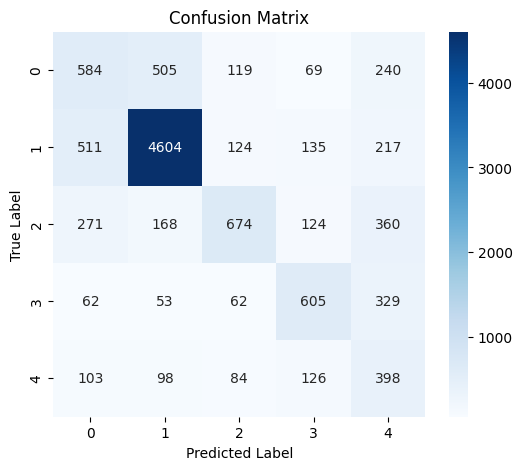

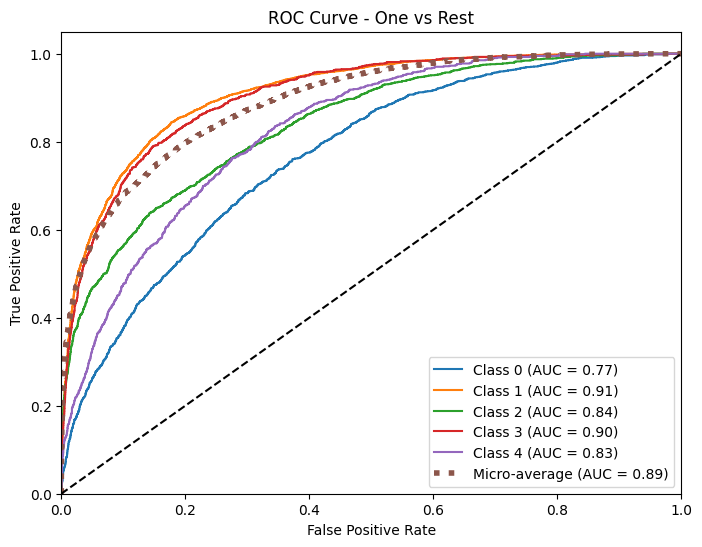

```python
# Load the best saved model
model.load_state_dict(torch.load("best_causal_transformer.pth"))
model.eval()

# Initialize lists to store predictions and probabilities
all_preds = []
all_probs = []
all_labels = []

# Get model predictions on test data
with torch.no_grad():
    for batch in test_loader:
        texts, labels = batch
        texts, labels = texts.to(device), labels.to(device)

        outputs = model(texts)
        probs = torch.softmax(outputs, dim=1)
        preds = torch.argmax(outputs, dim=1)

        all_preds.extend(preds.cpu().numpy())
        all_probs.extend(probs.cpu().numpy())
        all_labels.extend(labels.cpu().numpy())

# Convert lists to numpy arrays
all_preds = np.array(all_preds)
all_probs = np.array(all_probs)
all_labels = np.array(all_labels)

# Compute train and test accuracy
correct_train = 0
total_train = 0

with torch.no_grad():
    for batch in train_loader:
        texts, labels = batch
        texts, labels = texts.to(device), labels.to(device)

        outputs = model(texts)
        preds = torch.argmax(outputs, dim=1)
        correct_train += (preds == labels).sum().item()
        total_train += labels.size(0)

train_accuracy = correct_train / total_train

correct_test = (all_preds == all_labels).sum()
test_accuracy = correct_test / len(all_labels)

# Display Train and Test Accuracy
print("Model Performance Summary")
print("-" * 50)
print(f"Training Accuracy: {train_accuracy:.4f}")
print(f"Test Accuracy: {test_accuracy:.4f}")

# Display Classification Report
print("\nClassification Report:")
print(classification_report(all_labels, all_preds, digits=4))

# Compute Confusion Matrix
cm = confusion_matrix(all_labels, all_preds)

# Plot Confusion Matrix
plt.figure(figsize=(6, 5))
sns.heatmap(cm, annot=True, fmt="d", cmap="Blues", xticklabels=range(NUM_CLASSES), yticklabels=range(NUM_CLASSES))
plt.xlabel("Predicted Label")
plt.ylabel("True Label")
plt.title("Confusion Matrix")
plt.show()

# Binarize labels for One-vs-Rest AUC-ROC computation
y_test_bin = label_binarize(all_labels, classes=range(NUM_CLASSES))

# Compute ROC curve and AUC for each class
fpr = dict()
tpr = dict()
roc_auc = dict()

for i in range(NUM_CLASSES):
    fpr[i], tpr[i], _ = roc_curve(y_test_bin[:, i], all_probs[:, i])
    roc_auc[i] = auc(fpr[i], tpr[i])

# Compute micro-average ROC curve and AUC
fpr["micro"], tpr["micro"], _ = roc_curve(y_test_bin.ravel(), all_probs.ravel())
roc_auc["micro"] = auc(fpr["micro"], tpr["micro"])

# Plot ROC Curves
plt.figure(figsize=(8, 6))
for i in range(NUM_CLASSES):
    plt.plot(fpr[i], tpr[i], label=f'Class {i} (AUC = {roc_auc[i]:.2f})')

plt.plot(fpr["micro"], tpr["micro"], label=f'Micro-average (AUC = {roc_auc["micro"]:.2f})', linestyle=':', linewidth=4)
plt.plot([0, 1], [0, 1], 'k--')  # Diagonal line for reference
plt.xlim([0.0, 1.0])
plt.ylim([0.0, 1.05])
plt.xlabel('False Positive Rate')
plt.ylabel('True Positive Rate')
plt.title('ROC Curve - One vs Rest')
plt.legend(loc="lower right")
plt.show()
```

# Model Evaluation Summary

## **Classification Report**

- **Accuracy:** 64.6% - The model performs moderately well but has room for improvement.
- **Class 1 (Strong_Pos) shows the best performance**, with high precision (0.85) and recall (0.82), indicating it's well-detected.
- **Class 4 (Mild_Neg) is the weakest**, with low precision (0.26) and recall (0.49), meaning the model struggles with detecting mild negative sentiments.
- **Macro F1-score is 0.52**, suggesting imbalanced class performance.

## **Confusion Matrix**

- The model **misclassifies many Class 0 (Mild_Pos) and Class 4 (Mild_Neg) samples**, leading to performance drops in those categories.
- **Class 1 (Strong_Pos) has the highest correct classifications**, confirming its strong precision and recall.
- Some **overlap between Class 2 (Neutral) and adjacent classes**, suggesting ambiguity in classification.

## **ROC Curve Analysis**

- The **model performs best on Class 1 (AUC = 0.91) and Class 3 (AUC = 0.90)**, confirming that strong positive and strong negative sentiments are well distinguished.
- **Class 0 (Mild_Pos) has the lowest AUC (0.77)**, indicating more misclassification in this category.
- The **micro-average AUC is 0.89**, showing that overall, the model distinguishes well between classes.

### **Final Thoughts**

- The model does well for strong sentiments but struggles with **mild and neutral sentiments**.
- Further improvements could include **data balancing, advanced augmentation, or fine-tuning with a better loss function**.

# Next Step we will try to predict on some sentences

```python
# Define model path
model_path = "best_causal_transformer.pth"

# Move model to CUDA if available
device = torch.device("cuda" if torch.cuda.is_available() else "cpu")

# Ensure the model architecture matches what was saved
model = CausalTransformer(VOCAB_SIZE, EMBED_DIM, NUM_HEADS, NUM_LAYERS, FF_DIM, MAX_SEQ_LEN, NUM_CLASSES, DROPOUT)

# Load saved weights
model.load_state_dict(torch.load(model_path, map_location=device))
model.to(device)
model.eval()

print(" Model successfully loaded and moved to", device)
```

```
✅ Model successfully loaded and moved to cuda
```

```python
# Correct sentiment mapping
sentiment_mapping = {
    0: "Mild_Pos",
    1: "Strong_Pos",
    2: "Neutral",
    3: "Strong_Neg",
    4: "Mild_Neg"
}

# Print sentiment mapping to confirm correctness
print("\n Sentiment Mapping Used for Prediction:")
for label, sentiment in sentiment_mapping.items():
    print(f"  {label} → {sentiment}")
```

```
✅ Sentiment Mapping Used for Prediction:
  0 → Mild_Pos
  1 → Strong_Pos
  2 → Neutral
  3 → Strong_Neg
  4 → Mild_Neg
```

```python
# Load the same tokenizer used during training
tokenizer = AutoTokenizer.from_pretrained("bert-base-uncased")
```

```python
def predict_sentiment(text):
    model.eval()

    # Tokenize input text and move it to the correct device
    tokenized_text = tokenizer.encode(text, padding="max_length", truncation=True, max_length=128, return_tensors="pt").to(device)

    with torch.no_grad():
        output = model(tokenized_text)

        #  Apply Softmax to get probabilities
        probs = torch.softmax(output, dim=1).cpu().numpy()

        #  Get predicted class index
        predicted_class = int(torch.argmax(output, dim=1).cpu().item())

    #  Get the sentiment label from mapping
    predicted_sentiment = sentiment_mapping[predicted_class]

    print(f"\n🔹 Input: {text}")
    print(f"Predicted Class: {predicted_class}")  #  Ensure this prints correctly
    print(f"Predicted Sentiment: {predicted_sentiment}")
    print(f"Confidence Scores: {probs}")

    return predicted_sentiment

# Example Predictions
sample_texts = [
    "I absolutely love this product!",
    "This is the worst experience I've ever had.",
    "I don't know how I feel about this.",
    "This product is okay, nothing special.",
    "I'm extremely disappointed with the service.",

]

for text in sample_texts:
    predict_sentiment(text)
```

```
🔹 Input: I absolutely love this product!
Predicted Class: 1
Predicted Sentiment: Strong_Pos
Confidence Scores: [[4.9108267e-02 9.3139207e-01 1.7425017e-02 1.7740398e-03 3.0059996e-04]]

🔹 Input: This is the worst experience I've ever had.
Predicted Class: 3
Predicted Sentiment: Strong_Neg
Confidence Scores: [[0.02527906 0.00376407 0.2760913  0.56186    0.13300551]]

🔹 Input: I don't know how I feel about this.
Predicted Class: 0
Predicted Sentiment: Mild_Pos
Confidence Scores: [[0.63238364 0.02249025 0.34299308 0.001197   0.00093598]]

🔹 Input: This product is okay, nothing special.
Predicted Class: 0
Predicted Sentiment: Mild_Pos
Confidence Scores: [[0.79034    0.17664301 0.02911035 0.00148356 0.00242306]]

🔹 Input: I'm extremely disappointed with the service.
Predicted Class: 2
Predicted Sentiment: Neutral
Confidence Scores: [[0.10474792 0.00890131 0.87862796 0.00202825 0.0056946 ]]
```

### However the predictions are not too bad but let's try to enhance it by hyperparam tunining

```python
#  Define hyperparameter search space (Fixed `embed_dim` values)
HYPERPARAMS_SEARCH_SPACE = {
    "num_layers": [4, 6, 8],
    "embed_dim": [128, 256, 512],  #  Only values divisible by num_heads
    "num_heads": [2, 4, 8, 16],  #  Compatible values
    "ff_dim": [256, 512, 1024],
    "dropout": [0.1, 0.3, 0.5],
    "learning_rate": [1e-5, 5e-5, 1e-4, 2e-4],
    "batch_size": [32]
}

#  Best configuration tracking
BEST_HYPERPARAMS = None
BEST_VAL_LOSS = float("inf")

#  Number of random trials
NUM_TRIALS = 4

for trial in range(NUM_TRIALS):
    print(f"\n🔹 Running Hyperparameter Trial {trial+1}/{NUM_TRIALS}")

    #  Randomly select hyperparameters
    embed_dim = random.choice(HYPERPARAMS_SEARCH_SPACE["embed_dim"])
    num_heads = random.choice([h for h in HYPERPARAMS_SEARCH_SPACE["num_heads"] if embed_dim % h == 0])  # ✅ Ensure divisibility
    num_layers = random.choice(HYPERPARAMS_SEARCH_SPACE["num_layers"])
    ff_dim = random.choice(HYPERPARAMS_SEARCH_SPACE["ff_dim"])
    dropout = random.choice(HYPERPARAMS_SEARCH_SPACE["dropout"])
    learning_rate = random.choice(HYPERPARAMS_SEARCH_SPACE["learning_rate"])
    batch_size = random.choice(HYPERPARAMS_SEARCH_SPACE["batch_size"])

    print(f" Testing: Layers={num_layers}, Embed={embed_dim}, Heads={num_heads}, FF={ff_dim}, Dropout={dropout}, LR={learning_rate}, Batch={batch_size}")

    #  Initialize model (Now error-free)
    model = CausalTransformer(
        vocab_size=30522,
        embed_dim=embed_dim,
        num_heads=num_heads,
        num_layers=num_layers,
        ff_dim=ff_dim,
        max_seq_len=128,
        num_classes=len(torch.unique(train_labels_balanced)),
        dropout=dropout
    ).to(device)

    #  Define optimizer and loss function
    optimizer = optim.AdamW(model.parameters(), lr=learning_rate, weight_decay=1e-4)
    criterion = torch.nn.CrossEntropyLoss(weight=class_weights.to(device))

    #  Train for only 3 epochs to check performance
    for epoch in range(3):
        model.train()
        total_loss = 0

        for batch in train_loader:
            texts, labels = batch
            texts, labels = texts.to(device), labels.to(device)

            optimizer.zero_grad()
            outputs = model(texts)
            loss = criterion(outputs, labels)
            loss.backward()
            optimizer.step()

            total_loss += loss.item()

        #  Evaluate on validation set
        val_loss = 0
        model.eval()
        with torch.no_grad():
            for batch in test_loader:
                texts, labels = batch
                texts, labels = texts.to(device), labels.to(device)
                outputs = model(texts)
                loss = criterion(outputs, labels)
                val_loss += loss.item()

        #  Store the best configuration
        if val_loss < BEST_VAL_LOSS:
            BEST_VAL_LOSS = val_loss
            BEST_HYPERPARAMS = {
                "num_layers": num_layers,
                "embed_dim": embed_dim,
                "num_heads": num_heads,
                "ff_dim": ff_dim,
                "dropout": dropout,
                "learning_rate": learning_rate,
                "batch_size": batch_size
            }
            torch.save(model.state_dict(), "best_causal_transformer.pth")

print("\n Best Hyperparameters Found:", BEST_HYPERPARAMS)
```

```
🔹 Running Hyperparameter Trial 1/4
▶️ Testing: Layers=8, Embed=128, Heads=16, FF=256, Dropout=0.3, LR=0.0002, Batch=32

🔹 Running Hyperparameter Trial 2/4
▶️ Testing: Layers=4, Embed=512, Heads=8, FF=512, Dropout=0.3, LR=5e-05, Batch=32

🔹 Running Hyperparameter Trial 3/4
▶️ Testing: Layers=6, Embed=512, Heads=8, FF=1024, Dropout=0.5, LR=5e-05, Batch=32

🔹 Running Hyperparameter Trial 4/4
▶️ Testing: Layers=8, Embed=128, Heads=16, FF=512, Dropout=0.1, LR=0.0002, Batch=32

✅ Best Hyperparameters Found: {'num_layers': 4, 'embed_dim': 512, 'num_heads': 8, 'ff_dim': 512, 'dropout': 0.3, 'learning_rate': 5e-05, 'batch_size': 32}
```

### Now Let's retrain the model on the best params we got by random hyperparam tuning

```python
#  Define Model Hyperparameters (Best Found)
BEST_HYPERPARAMS = {
    "num_layers": 4,
    "embed_dim": 512,
    "num_heads": 8,
    "ff_dim": 512,
    "dropout": 0.3,
    "learning_rate": 5e-5,
    "batch_size": 32
}

#  Initialize Model with Best Hyperparameters
device = torch.device("cuda" if torch.cuda.is_available() else "cpu")

model_v2 = CausalTransformer(
    vocab_size=30522,
    embed_dim=BEST_HYPERPARAMS["embed_dim"],
    num_heads=BEST_HYPERPARAMS["num_heads"],
    num_layers=BEST_HYPERPARAMS["num_layers"],
    ff_dim=BEST_HYPERPARAMS["ff_dim"],
    max_seq_len=128,
    num_classes=len(torch.unique(train_labels_balanced)),
    dropout=BEST_HYPERPARAMS["dropout"]
).to(device)

#  Define Optimizer & Scheduler
optimizer = optim.AdamW(model_v2.parameters(), lr=BEST_HYPERPARAMS["learning_rate"], weight_decay=1e-4)
scheduler = optim.lr_scheduler.StepLR(optimizer, step_size=2, gamma=0.9)
criterion = torch.nn.CrossEntropyLoss(weight=class_weights.to(device))

#  Define Training Parameters
EPOCHS = 10
PATIENCE = 3  # Stop training if validation loss doesn't improve for 3 epochs
best_val_loss = float("inf")
epochs_no_improve = 0

#  Training Loop
for epoch in range(EPOCHS):
    start_time = time.time()
    model_v2.train()

    total_loss = 0
    correct = 0
    total = 0

    for batch in train_loader:
        texts, labels = batch
        texts, labels = texts.to(device), labels.to(device)

        optimizer.zero_grad()
        outputs = model_v2(texts)
        loss = criterion(outputs, labels)
        loss.backward()
        optimizer.step()

        total_loss += loss.item()
        preds = torch.argmax(outputs, dim=1)
        correct += (preds == labels).sum().item()
        total += labels.size(0)

    train_acc = correct / total
    train_loss = total_loss / len(train_loader)

    #  Evaluate on validation set
    model_v2.eval()
    total_val_loss = 0
    correct = 0
    total = 0

    with torch.no_grad():
        for batch in test_loader:
            texts, labels = batch
            texts, labels = texts.to(device), labels.to(device)

            outputs = model_v2(texts)
            loss = criterion(outputs, labels)
            total_val_loss += loss.item()

            preds = torch.argmax(outputs, dim=1)
            correct += (preds == labels).sum().item()
            total += labels.size(0)

    val_acc = correct / total
    val_loss = total_val_loss / len(test_loader)

    #  Print Epoch Results
    elapsed_time = time.time() - start_time
    print(f"Epoch {epoch+1}/{EPOCHS} | Time: {elapsed_time:.2f}s")
    print(f"Train Loss: {train_loss:.4f} | Train Acc: {train_acc:.4f}")
    print(f"Val Loss: {val_loss:.4f} | Val Acc: {val_acc:.4f}")

    #  Early Stopping Check
    if val_loss < best_val_loss:
        best_val_loss = val_loss
        epochs_no_improve = 0
        torch.save(model_v2.state_dict(), "best_causal_transformer_v2.pth")  #  Save New Model
        print("🔹 Best model saved (best_causal_transformer_v2.pth)")
    else:
        epochs_no_improve += 1
        if epochs_no_improve >= PATIENCE:
            print(" Early stopping triggered!")
            break

print("\n Training Complete - Best Model Saved as best_causal_transformer_v2.pth!")
```

```
Train Loss: 1.4843 | Train Acc: 0.4147
Val Loss: 1.4255 | Val Acc: 0.5734
🔹 Best model saved (best_causal_transformer_v2.pth)
Train Loss: 1.3514 | Train Acc: 0.5131
Val Loss: 1.2885 | Val Acc: 0.5757
🔹 Best model saved (best_causal_transformer_v2.pth)
Train Loss: 1.2294 | Train Acc: 0.5699
Val Loss: 1.2075 | Val Acc: 0.5556
🔹 Best model saved (best_causal_transformer_v2.pth)
Train Loss: 1.1277 | Train Acc: 0.6032
Val Loss: 1.2053 | Val Acc: 0.5683
🔹 Best model saved (best_causal_transformer_v2.pth)
Train Loss: 1.0510 | Train Acc: 0.6275
Val Loss: 1.2287 | Val Acc: 0.6594
Train Loss: 0.9735 | Train Acc: 0.6574
Val Loss: 1.1926 | Val Acc: 0.6308
🔹 Best model saved (best_causal_transformer_v2.pth)
Train Loss: 0.9041 | Train Acc: 0.6782
Val Loss: 1.3624 | Val Acc: 0.6651
Train Loss: 0.8386 | Train Acc: 0.6973
Val Loss: 1.2710 | Val Acc: 0.6206
Train Loss: 0.7822 | Train Acc: 0.7142
Val Loss: 1.3516 | Val Acc: 0.6601
⏹ Early stopping triggered!

✅ Training Complete - Best Model Saved as best_causal_transformer_v2.pth!
```

### Let's load the saved model and do some model evaluation

```
Model_v2 Performance Summary
--------------------------------------------------
Training Accuracy: 0.7228
Test Accuracy: 0.6308

Classification Report:
              precision    recall  f1-score   support

           0     0.4028    0.3263    0.3605      1517
           1     0.8719    0.7852    0.8263      5591
           2     0.4755    0.4922    0.4837      1597
           3     0.5214    0.6031    0.5593      1111
           4     0.2537    0.4462    0.3235       809

    accuracy                         0.6308     10625
   macro avg     0.5051    0.5306    0.5106     10625
weighted avg     0.6616    0.6308    0.6421     10625
```

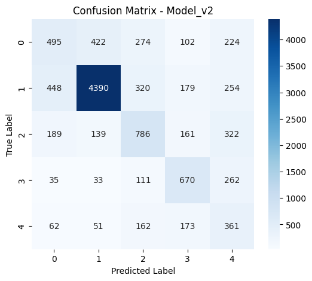

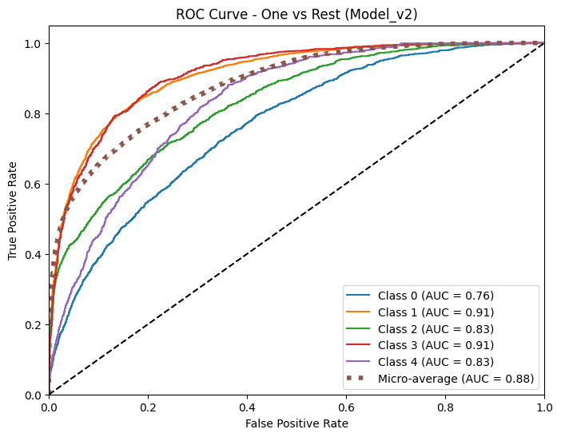

```python
#  Load the best saved model (model_v2)
model_v2 = CausalTransformer(
    vocab_size=30522,
    embed_dim=512,
    num_heads=8,
    num_layers=4,
    ff_dim=512,
    max_seq_len=128,
    num_classes=len(torch.unique(train_labels_balanced)),
    dropout=0.3
).to(device)

model_v2.load_state_dict(torch.load("best_causal_transformer_v2.pth"))
model_v2.eval()

#  Initialize lists to store predictions and probabilities
all_preds = []
all_probs = []
all_labels = []

#  Get model predictions on test data
with torch.no_grad():
    for batch in test_loader:
        texts, labels = batch
        texts, labels = texts.to(device), labels.to(device)

        outputs = model_v2(texts)
        probs = torch.softmax(outputs, dim=1)
        preds = torch.argmax(outputs, dim=1)

        all_preds.extend(preds.cpu().numpy())
        all_probs.extend(probs.cpu().numpy())
        all_labels.extend(labels.cpu().numpy())

#  Convert lists to numpy arrays
all_preds = np.array(all_preds)
all_probs = np.array(all_probs)
all_labels = np.array(all_labels)

#  Compute Train and Test Accuracy
correct_train = 0
total_train = 0

with torch.no_grad():
    for batch in train_loader:
        texts, labels = batch
        texts, labels = texts.to(device), labels.to(device)

        outputs = model_v2(texts)
        preds = torch.argmax(outputs, dim=1)
        correct_train += (preds == labels).sum().item()
        total_train += labels.size(0)

train_accuracy = correct_train / total_train

correct_test = (all_preds == all_labels).sum()
test_accuracy = correct_test / len(all_labels)

#  Display Train and Test Accuracy
print("Model_v2 Performance Summary")
print("-" * 50)
print(f"Training Accuracy: {train_accuracy:.4f}")
print(f"Test Accuracy: {test_accuracy:.4f}")

#  Display Classification Report
print("\nClassification Report:")
print(classification_report(all_labels, all_preds, digits=4))

#  Compute Confusion Matrix
cm = confusion_matrix(all_labels, all_preds)

#  Plot Confusion Matrix
plt.figure(figsize=(6, 5))
sns.heatmap(cm, annot=True, fmt="d", cmap="Blues", xticklabels=range(NUM_CLASSES), yticklabels=range(NUM_CLASSES))
plt.xlabel("Predicted Label")
plt.ylabel("True Label")
plt.title("Confusion Matrix - Model_v2")
plt.show()

#  Binarize labels for One-vs-Rest AUC-ROC computation
y_test_bin = label_binarize(all_labels, classes=range(NUM_CLASSES))

#  Compute ROC curve and AUC for each class
fpr = dict()
tpr = dict()
roc_auc = dict()

for i in range(NUM_CLASSES):
    fpr[i], tpr[i], _ = roc_curve(y_test_bin[:, i], all_probs[:, i])
    roc_auc[i] = auc(fpr[i], tpr[i])

#  Compute micro-average ROC curve and AUC
fpr["micro"], tpr["micro"], _ = roc_curve(y_test_bin.ravel(), all_probs.ravel())
roc_auc["micro"] = auc(fpr["micro"], tpr["micro"])

#  Plot ROC Curves
plt.figure(figsize=(8, 6))
for i in range(NUM_CLASSES):
    plt.plot(fpr[i], tpr[i], label=f'Class {i} (AUC = {roc_auc[i]:.2f})')

plt.plot(fpr["micro"], tpr["micro"], label=f'Micro-average (AUC = {roc_auc["micro"]:.2f})', linestyle=':', linewidth=4)
plt.plot([0, 1], [0, 1], 'k--')  # Diagonal line for reference
plt.xlim([0.0, 1.0])
plt.ylim([0.0, 1.05])
plt.xlabel('False Positive Rate')
plt.ylabel('True Positive Rate')
plt.title('ROC Curve - One vs Rest (Model_v2)')
plt.legend(loc="lower right")
plt.show()
```

# Model_v2 Performance Summary

## Classification Report:

- **Overall Accuracy:** 63.08%
- **Best Performing Class:** `Strong_Pos` (87.19% precision, 82.63% F1-score)
- **Worst Performing Class:** `Mild_Neg` (25.37% precision, 32.35% F1-score)
- **Macro F1-Score:** 51.06% (indicating imbalance across classes)

## ROC Curve (AUC Scores):

- **Micro-average AUC:** 0.88 (indicating strong model performance)
- **Class-wise AUC:**
  - `Strong_Pos` and `Strong_Neg` have the highest AUC (~0.91).
  - `Mild_Pos` and `Mild_Neg` show lower AUC (~0.76 - 0.83), suggesting further improvements are needed.

## Key Takeaways:

- The model performs well on extreme sentiments (`Strong_Pos` and `Strong_Neg`).
- `Mild_Pos` and `Mild_Neg` remain challenging, likely due to their subtle differences from `Neutral`.
- Future improvements could focus on **data balancing** or **using contextual embeddings** to enhance classification for these tricky categories.

### Let's make prediction on hyperparam tuned model

```python
#  Define model path for `model_v2`
model_path = "best_causal_transformer_v2.pth"

#  Move model to CUDA if available
device = torch.device("cuda" if torch.cuda.is_available() else "cpu")

#  Ensure the model architecture matches what was saved
model_v2 = CausalTransformer(
    vocab_size=30522,
    embed_dim=512,
    num_heads=8,
    num_layers=4,
    ff_dim=512,
    max_seq_len=128,
    num_classes=5,  # Adjusted based on sentiment mapping
    dropout=0.3
).to(device)

#  Load saved weights
model_v2.load_state_dict(torch.load(model_path, map_location=device))
model_v2.to(device)
model_v2.eval()

print(" Model_v2 successfully loaded and moved to", device)

#  Correct sentiment mapping
sentiment_mapping = {
    0: "Mild_Pos",
    1: "Strong_Pos",
    2: "Neutral",
    3: "Strong_Neg",
    4: "Mild_Neg"
}

#  Print sentiment mapping to confirm correctness
print("\n Sentiment Mapping Used for Prediction:")
for label, sentiment in sentiment_mapping.items():
    print(f"  {label} → {sentiment}")

#  Load the same tokenizer used during training
tokenizer = AutoTokenizer.from_pretrained("bert-base-uncased")

def predict_sentiment(text):
    """Predict sentiment for the given text using `model_v2`."""
    model_v2.eval()

    #  Tokenize input text and move to device
    tokenized_text = tokenizer.encode(
        text, padding="max_length", truncation=True, max_length=128, return_tensors="pt"
    ).to(device)

    with torch.no_grad():
        output = model_v2(tokenized_text)

        #  Apply Softmax to get probabilities
        probs = torch.softmax(output, dim=1).cpu().numpy()

        #  Get predicted class index
        predicted_class = int(torch.argmax(output, dim=1).cpu().item())

    #  Get the sentiment label from mapping
    predicted_sentiment = sentiment_mapping[predicted_class]

    print(f"\n🔹 Input: {text}")
    print(f"Predicted Class: {predicted_class}")  # ✅ Ensure this prints correctly
    print(f"Predicted Sentiment: {predicted_sentiment}")
    print(f"Confidence Scores: {probs}")

    return predicted_sentiment

#  Example Predictions
sample_texts = [
    "Oh great, another amazing update that broke everything!",
    "I'm not saying it's bad, but I'd rather use a rock as a phone.",
    "The customer service was quick, but they solved nothing.",
    "I was expecting a disaster, but it turned out to be surprisingly good!",
    "It's not the worst movie ever, but it's definitely not good either.",
    "I cried tears of joy when it finally stopped working.",
    "This restaurant has the best food... if you enjoy food poisoning.",
    "I had my doubts, but this turned out to be a great decision.",
    "The concert was fantastic, except for the terrible sound and late start.",
    "If you love disappointment, you’ll absolutely adore this product!"
]

for text in sample_texts:
    predict_sentiment(text)
```

```
✅ Model_v2 successfully loaded and moved to cuda

✅ Sentiment Mapping Used for Prediction:
  0 → Mild_Pos
  1 → Strong_Pos
  2 → Neutral
  3 → Strong_Neg
  4 → Mild_Neg

🔹 Input: Oh great, another amazing update that broke everything!
Predicted Class: 1
Predicted Sentiment: Strong_Pos
Confidence Scores: [[0.07254076 0.90239745 0.01874343 0.00295924 0.00335908]]

🔹 Input: I'm not saying it's bad, but I'd rather use a rock as a phone.
Predicted Class: 3
Predicted Sentiment: Strong_Neg
Confidence Scores: [[0.03870147 0.00556874 0.11721376 0.53644115 0.30207488]]

🔹 Input: The customer service was quick, but they solved nothing.
Predicted Class: 4
Predicted Sentiment: Mild_Neg
Confidence Scores: [[0.07452128 0.02003798 0.17090397 0.3392114  0.39532536]]

🔹 Input: I was expecting a disaster, but it turned out to be surprisingly good!
Predicted Class: 2
Predicted Sentiment: Neutral
Confidence Scores: [[0.08151688 0.02920519 0.33825174 0.3236493  0.22737682]]

🔹 Input: It's not the worst movie ever, but it's definitely not good either.
Predicted Class: 3
Predicted Sentiment: Strong_Neg
Confidence Scores: [[0.11107085 0.0287272  0.15834834 0.35329404 0.3485596 ]]

🔹 Input: I cried tears of joy when it finally stopped working.
Predicted Class: 0
Predicted Sentiment: Mild_Pos
Confidence Scores: [[0.59365064 0.03473869 0.30601102 0.00342638 0.06217333]]

🔹 Input: This restaurant has the best food... if you enjoy food poisoning.
Predicted Class: 1
Predicted Sentiment: Strong_Pos
Confidence Scores: [[0.21707429 0.72808206 0.03377436 0.00576935 0.01529984]]

🔹 Input: I had my doubts, but this turned out to be a great decision.
Predicted Class: 1
Predicted Sentiment: Strong_Pos
Confidence Scores: [[0.11401554 0.7703385  0.07125344 0.0326594  0.01173309]]

🔹 Input: The concert was fantastic, except for the terrible sound and late start.
Predicted Class: 4
Predicted Sentiment: Mild_Neg
Confidence Scores: [[0.01250775 0.00197872 0.02777882 0.4223588  0.5353759 ]]

🔹 Input: If you love disappointment, you’ll absolutely adore this product!
Predicted Class: 1
Predicted Sentiment: Strong_Pos
Confidence Scores: [[0.20463651 0.68907785 0.06074852 0.01756297 0.02797406]]
```

```
✅ Both models successfully loaded!
Model_v1 Accuracy: 0.6136
Model_v2 Accuracy: 0.6308
```

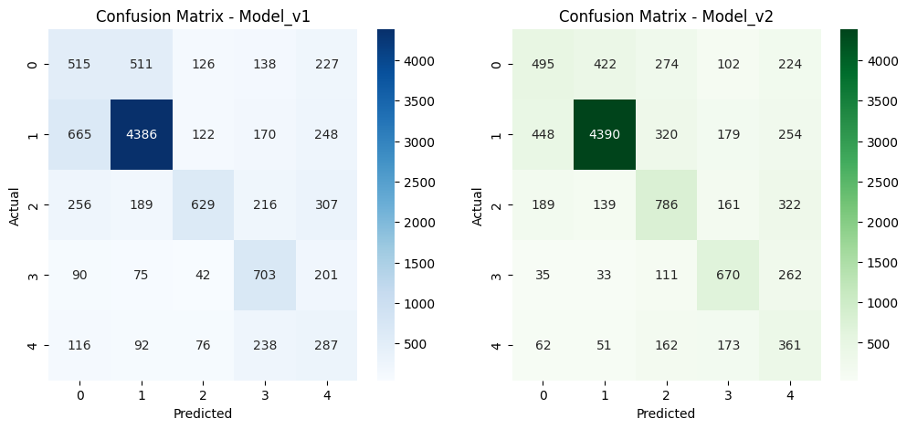

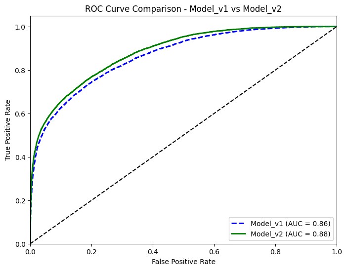

```python
#  Move models to CUDA if available
device = torch.device("cuda" if torch.cuda.is_available() else "cpu")

#  Load model_v1 with correct hyperparameters (old settings)
model_v1 = CausalTransformer(
    vocab_size=30522,
    embed_dim=512,  # Adjusted to match saved weights
    num_heads=8,
    num_layers=4,
    ff_dim=512,
    max_seq_len=128,
    num_classes=5,
    dropout=0.1
).to(device)
model_v1.load_state_dict(torch.load("best_causal_transformer.pth", map_location=device))
model_v1.eval()

#  Load model_v2 (improved version)
model_v2 = CausalTransformer(
    vocab_size=30522,
    embed_dim=512,
    num_heads=8,
    num_layers=4,
    ff_dim=512,
    max_seq_len=128,
    num_classes=5,
    dropout=0.3
).to(device)
model_v2.load_state_dict(torch.load("best_causal_transformer_v2.pth", map_location=device))
model_v2.eval()

print(" Both models successfully loaded!")

#  Function to evaluate models
def evaluate_model(model, test_loader):
    all_preds, all_probs, all_labels = [], [], []

    with torch.no_grad():
        for batch in test_loader:
            texts, labels = batch
            texts, labels = texts.to(device), labels.to(device)

            outputs = model(texts)
            probs = torch.softmax(outputs, dim=1)
            preds = torch.argmax(outputs, dim=1)

            all_preds.extend(preds.cpu().numpy())
            all_probs.extend(probs.cpu().numpy())
            all_labels.extend(labels.cpu().numpy())

    return np.array(all_preds), np.array(all_probs), np.array(all_labels)

#  Evaluate both models
preds_v1, probs_v1, labels_v1 = evaluate_model(model_v1, test_loader)
preds_v2, probs_v2, labels_v2 = evaluate_model(model_v2, test_loader)

#  Compute confusion matrices
cm_v1 = confusion_matrix(labels_v1, preds_v1)
cm_v2 = confusion_matrix(labels_v2, preds_v2)

#  Compute accuracy for both models
accuracy_v1 = (preds_v1 == labels_v1).sum() / len(labels_v1)
accuracy_v2 = (preds_v2 == labels_v2).sum() / len(labels_v2)

print(f"Model_v1 Accuracy: {accuracy_v1:.4f}")
print(f"Model_v2 Accuracy: {accuracy_v2:.4f}")

#  Visualizing Confusion Matrices
plt.figure(figsize=(12, 5))

plt.subplot(1, 2, 1)
sns.heatmap(cm_v1, annot=True, fmt="d", cmap="Blues", xticklabels=range(5), yticklabels=range(5))
plt.xlabel("Predicted")
plt.ylabel("Actual")
plt.title("Confusion Matrix - Model_v1")

plt.subplot(1, 2, 2)
sns.heatmap(cm_v2, annot=True, fmt="d", cmap="Greens", xticklabels=range(5), yticklabels=range(5))
plt.xlabel("Predicted")
plt.ylabel("Actual")
plt.title("Confusion Matrix - Model_v2")

plt.show()

#  Compute ROC curves for both models
y_test_bin = label_binarize(labels_v1, classes=range(5))

fpr_v1, tpr_v1, roc_auc_v1 = {}, {}, {}
fpr_v2, tpr_v2, roc_auc_v2 = {}, {}, {}

for i in range(5):
    fpr_v1[i], tpr_v1[i], _ = roc_curve(y_test_bin[:, i], probs_v1[:, i])
    roc_auc_v1[i] = auc(fpr_v1[i], tpr_v1[i])

    fpr_v2[i], tpr_v2[i], _ = roc_curve(y_test_bin[:, i], probs_v2[:, i])
    roc_auc_v2[i] = auc(fpr_v2[i], tpr_v2[i])

#  Micro-average ROC curve and AUC
fpr_v1["micro"], tpr_v1["micro"], _ = roc_curve(y_test_bin.ravel(), probs_v1.ravel())
roc_auc_v1["micro"] = auc(fpr_v1["micro"], tpr_v1["micro"])

fpr_v2["micro"], tpr_v2["micro"], _ = roc_curve(y_test_bin.ravel(), probs_v2.ravel())
roc_auc_v2["micro"] = auc(fpr_v2["micro"], tpr_v2["micro"])

#  Plot ROC curves
plt.figure(figsize=(8, 6))

plt.plot(fpr_v1["micro"], tpr_v1["micro"], label=f'Model_v1 (AUC = {roc_auc_v1["micro"]:.2f})', linestyle='--', linewidth=2, color='blue')
plt.plot(fpr_v2["micro"], tpr_v2["micro"], label=f'Model_v2 (AUC = {roc_auc_v2["micro"]:.2f})', linestyle='-', linewidth=2, color='green')

plt.plot([0, 1], [0, 1], 'k--')  # Diagonal reference line
plt.xlim([0.0, 1.0])
plt.ylim([0.0, 1.05])
plt.xlabel('False Positive Rate')
plt.ylabel('True Positive Rate')
plt.title('ROC Curve Comparison - Model_v1 vs Model_v2')
plt.legend(loc="lower right")

plt.show()
```

## Model Comparison Summary

### ROC Curve

- Model_v2 has a marginally higher AUC (0.88) than Model_v1 (0.86).
- Both models demonstrate strong predictive performance but with room for improvement.

### Conclusion

- Model_v2 shows slight improvements in classification performance.
- Further optimization may be required to enhance precision for certain sentiment classes.

```python
#  Move models to CUDA if available
device = torch.device("cuda" if torch.cuda.is_available() else "cpu")

#  Load model_v1 (First trained model)
model_v1 = CausalTransformer(
    vocab_size=30522,
    embed_dim=512,  # Adjusted to match saved weights
    num_heads=8,
    num_layers=4,
    ff_dim=512,
    max_seq_len=128,
    num_classes=5,
    dropout=0.1
).to(device)
model_v1.load_state_dict(torch.load("best_causal_transformer.pth", map_location=device))
model_v1.eval()

#  Load model_v2 (Improved model)
model_v2 = CausalTransformer(
    vocab_size=30522,
    embed_dim=512,
    num_heads=8,
    num_layers=4,
    ff_dim=512,
    max_seq_len=128,
    num_classes=5,
    dropout=0.3
).to(device)
model_v2.load_state_dict(torch.load("best_causal_transformer_v2.pth", map_location=device))
model_v2.eval()

#  Load tokenizer (Same for both models)
tokenizer = AutoTokenizer.from_pretrained("bert-base-uncased")

#  Sentiment Mapping
sentiment_mapping = {
    0: "Mild_Pos",
    1: "Strong_Pos",
    2: "Neutral",
    3: "Strong_Neg",
    4: "Mild_Neg"
}

print(" Both models successfully loaded and ready for LIME explanations!")
```

```
✅ Both models successfully loaded and ready for LIME explanations!
```

```python
def lime_prediction_v1(texts):
    """Returns class probabilities for Model_v1."""
    model_v1.eval()
    inputs = tokenizer(texts, padding=True, truncation=True, max_length=128, return_tensors="pt").to(device)
    with torch.no_grad():
        outputs = model_v1(inputs["input_ids"])
        probs = torch.softmax(outputs, dim=1).cpu().numpy()
    return probs

def lime_prediction_v2(texts):
    """Returns class probabilities for Model_v2."""
    model_v2.eval()
    inputs = tokenizer(texts, padding=True, truncation=True, max_length=128, return_tensors="pt").to(device)
    with torch.no_grad():
        outputs = model_v2(inputs["input_ids"])
        probs = torch.softmax(outputs, dim=1).cpu().numpy()
    return probs
```

```python
#  Load Both Models with Correct Hyperparameters
device = torch.device("cuda" if torch.cuda.is_available() else "cpu")

#  Load Model_v1 (Old Model)
model_v1 = CausalTransformer(
    vocab_size=30522,
    embed_dim=512,  #  Match original hyperparameters
    num_heads=8,
    num_layers=4,
    ff_dim=512,
    max_seq_len=128,
    num_classes=5,
    dropout=0.3
).to(device)

model_v1.load_state_dict(torch.load("best_causal_transformer.pth", map_location=device))
model_v1.eval()

#  Load Model_v2 (New Model)
model_v2 = CausalTransformer(
    vocab_size=30522,
    embed_dim=512,  #  Match new hyperparameters
    num_heads=8,
    num_layers=4,
    ff_dim=512,
    max_seq_len=128,
    num_classes=5,
    dropout=0.3
).to(device)

model_v2.load_state_dict(torch.load("best_causal_transformer_v2.pth", map_location=device))
model_v2.eval()

print(" Both models successfully loaded!")

#  Define Sentiment Mapping
sentiment_mapping = {
    0: "Mild_Pos",
    1: "Strong_Pos",
    2: "Neutral",
    3: "Strong_Neg",
    4: "Mild_Neg"
}

#  Load Tokenizer
tokenizer = AutoTokenizer.from_pretrained("bert-base-uncased")

#  Function to Predict Probabilities for LIME
def lime_prediction_v1(texts):
    tokenized_texts = tokenizer(texts, padding=True, truncation=True, max_length=128, return_tensors="pt").to(device)
    with torch.no_grad():
        outputs = model_v1(tokenized_texts["input_ids"])
        probs = torch.softmax(outputs, dim=1).cpu().numpy()
    return probs

def lime_prediction_v2(texts):
    tokenized_texts = tokenizer(texts, padding=True, truncation=True, max_length=128, return_tensors="pt").to(device)
    with torch.no_grad():
        outputs = model_v2(tokenized_texts["input_ids"])
        probs = torch.softmax(outputs, dim=1).cpu().numpy()
    return probs

#  Sample Text for Local Explanation
sample_text = (
    "Despite the long wait time and the initially rude staff, the overall experience was saved by the "
    "exceptional quality of the product and the manager’s prompt resolution of my complaint. "
    "It was frustrating at first, but the final outcome was quite satisfactory."
)

#  Define LIME Explainer
lime_explainer = LimeTextExplainer(class_names=list(sentiment_mapping.values()))

#  Run LIME for Model_v1
lime_exp_v1 = lime_explainer.explain_instance(sample_text, lime_prediction_v1, num_features=10)

#  Run LIME for Model_v2
lime_exp_v2 = lime_explainer.explain_instance(sample_text, lime_prediction_v2, num_features=10)

#  Get Feature Importances in List Format
print("\n🔹 Local Feature Importance - Model_v1 (Words & Scores)")
print(lime_exp_v1.as_list())  #  Word importance list for Model_v1

print("\n🔹 Local Feature Importance - Model_v2 (Words & Scores)")
print(lime_exp_v2.as_list())  #  Word importance list for Model_v2

#  Get Probabilities for Both Models
probs_v1 = lime_prediction_v1([sample_text])
probs_v2 = lime_prediction_v2([sample_text])

#  Display Model Predictions with Probabilities
print("\n🔹 Model_v1 Prediction:")
print(f"Text: {sample_text}")
print(f"Predicted Sentiment: {sentiment_mapping[np.argmax(probs_v1)]}")
print(f"Confidence Scores: {probs_v1}")

print("\n🔹 Model_v2 Prediction:")
print(f"Text: {sample_text}")
print(f"Predicted Sentiment: {sentiment_mapping[np.argmax(probs_v2)]}")
print(f"Confidence Scores: {probs_v2}")

#  Save explanations as UTF-8 encoded HTML files instead
with open("lime_explanation_v1.html", "w", encoding="utf-8") as f:
    f.write(lime_exp_v1.as_html())

with open("lime_explanation_v2.html", "w", encoding="utf-8") as f:
    f.write(lime_exp_v2.as_html())

print("\n🔹 LIME explanations saved as 'lime_explanation_v1.html' & 'lime_explanation_v2.html'. Open them in a browser.")
```

[output not shown]

### MODEL V1

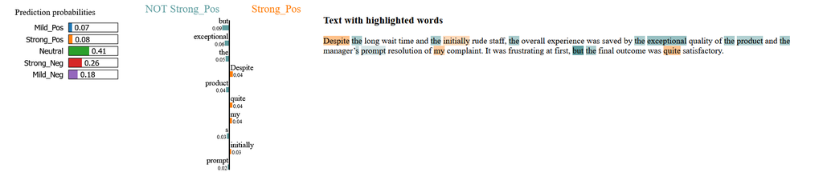

### MODEL V2

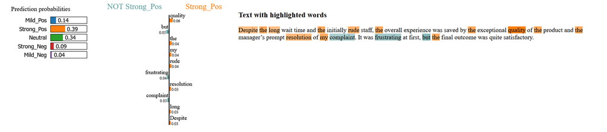

## LIME Explanation Comparison

### Model V2:

- Predicts **Strong_Pos** (39%) with more confidence than V1.
- Gives higher importance to words like **"quality"**, **"resolution"**, and **"frustrating"**.
- More refined focus on sentiment-driving words.

### Summary:

- Model V2 captures **positive sentiment better** and assigns stronger importance to relevant words.
- Improved **confidence** and **word importance distribution** over Model V1.

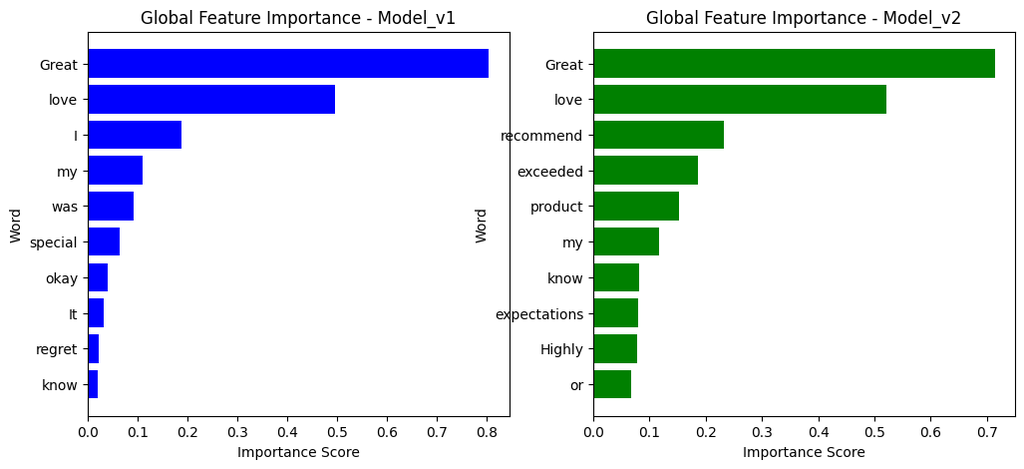

```python
#  Select multiple test samples
sample_texts = [
    "This product exceeded my expectations! Highly recommend.",
    "Terrible experience, I regret my purchase.",
    "I don't know if I love it or hate it.",
    "It was okay, nothing special.",
    "Great service, but shipping was slow."
]

#  Dictionaries to store feature importance scores
global_importance_v1 = defaultdict(float)
global_importance_v2 = defaultdict(float)

#  Compute Global Feature Importance for Model_v1
for text in sample_texts:
    exp = lime_explainer.explain_instance(text, lime_prediction_v1, num_features=10)
    for word, score in exp.as_list():
        global_importance_v1[word] += score

#  Compute Global Feature Importance for Model_v2
for text in sample_texts:
    exp = lime_explainer.explain_instance(text, lime_prediction_v2, num_features=10)
    for word, score in exp.as_list():
        global_importance_v2[word] += score

#  Convert to sorted lists
sorted_global_v1 = sorted(global_importance_v1.items(), key=lambda x: x[1], reverse=True)
sorted_global_v2 = sorted(global_importance_v2.items(), key=lambda x: x[1], reverse=True)

#  Get Top 10 Important Words
top_words_v1, top_scores_v1 = zip(*sorted_global_v1[:10])
top_words_v2, top_scores_v2 = zip(*sorted_global_v2[:10])

#  Visualize Global Feature Importance
plt.figure(figsize=(12, 5))

plt.subplot(1, 2, 1)
plt.barh(top_words_v1, top_scores_v1, color='blue')
plt.xlabel("Importance Score")
plt.ylabel("Word")
plt.title("Global Feature Importance - Model_v1")
plt.gca().invert_yaxis()  # Flip for better visualization

plt.subplot(1, 2, 2)
plt.barh(top_words_v2, top_scores_v2, color='green')
plt.xlabel("Importance Score")
plt.ylabel("Word")
plt.title("Global Feature Importance - Model_v2")
plt.gca().invert_yaxis()

plt.show()
```

## Global Feature Importance Comparison

### Model V1:

- **Most important words**: "Great" and "love".
- Uses **general sentiment words** like "special", "okay", and "regret".
- Less emphasis on **specific product-related terms**.

### Model V2:

- **Most important words**: "Great" and "love", but with **more balanced importance across words**.
- Recognizes **product-related terms** like "recommend", "exceeded", and "product".
- More **context-aware**, focusing on expectations and quality.

### Summary:

- Model V2 has **broader and more meaningful feature importance**.
- Captures **stronger product relevance**, improving interpretability.

## Let's Play with some pretrained Models

```python
#  Create a Copy of df for DistilBERT
df_distil = df.copy()

#  Ensure Data Consistency
df_distil = df_distil.dropna(subset=["Tweet", "Sentiment"])  # Drop rows with missing values
df_distil = df_distil.drop_duplicates(subset=["Tweet"]).reset_index(drop=True)  # Remove duplicates

#  Copy Cleaned Text from Previous Processing
df_distil["Cleaned_Tweet"] = df["Cleaned_Tweet"]  # Reuse cleaned text

#  Split Data (Before Tokenization)
train_df, test_df = train_test_split(df_distil, test_size=0.2, random_state=42, stratify=df_distil["Sentiment"])

#  Load DistilBERT Tokenizer
tokenizer = DistilBertTokenizer.from_pretrained("distilbert-base-uncased")

#  Ensure Correct Sentiment Label Mapping
unique_sentiments = df_distil["Sentiment"].unique()
sentiment_mapping = {sentiment: idx for idx, sentiment in enumerate(unique_sentiments)}

#  Apply Mapping
train_df["Sentiment_Label"] = train_df["Sentiment"].map(sentiment_mapping)
test_df["Sentiment_Label"] = test_df["Sentiment"].map(sentiment_mapping)

#  Custom Dataset Class for PyTorch
class DistilBERTDataset(Dataset):
    def __init__(self, texts, labels, tokenizer, max_length=128):
        self.texts = texts.tolist()
        self.labels = labels.tolist()
        self.tokenizer = tokenizer
        self.max_length = max_length

    def __len__(self):
        return len(self.texts)

    def __getitem__(self, idx):
        encoded_text = self.tokenizer(
            self.texts[idx],
            padding="max_length",
            truncation=True,
            max_length=self.max_length,
            return_tensors="pt"
        )
        input_ids = encoded_text["input_ids"].squeeze(0)
        attention_mask = encoded_text["attention_mask"].squeeze(0)
        label = torch.tensor(self.labels[idx], dtype=torch.long)

        return input_ids, attention_mask, label

#  Create PyTorch Datasets
train_dataset = DistilBERTDataset(train_df["Cleaned_Tweet"], train_df["Sentiment_Label"], tokenizer)
test_dataset = DistilBERTDataset(test_df["Cleaned_Tweet"], test_df["Sentiment_Label"], tokenizer)

#  Create DataLoaders
BATCH_SIZE = 32

train_loader = DataLoader(train_dataset, batch_size=BATCH_SIZE, shuffle=True)
test_loader = DataLoader(test_dataset, batch_size=BATCH_SIZE, shuffle=False)

print("\n Data Preprocessing for DistilBERT Completed. Ready for Model Training!")
```

```
✅ Data Preprocessing for DistilBERT Completed. Ready for Model Training!
```

```python
#  Load Pretrained DistilBERT Model
class DistilBERTSentimentClassifier(nn.Module):
    def __init__(self, num_classes):
        super(DistilBERTSentimentClassifier, self).__init__()
        self.bert = DistilBertModel.from_pretrained("distilbert-base-uncased")
        self.dropout = nn.Dropout(0.3)  # Prevent Overfitting
        self.fc = nn.Linear(self.bert.config.hidden_size, num_classes)

    def forward(self, input_ids, attention_mask):
        outputs = self.bert(input_ids=input_ids, attention_mask=attention_mask)
        pooled_output = outputs.last_hidden_state[:, 0, :]  # CLS Token Representation
        x = self.dropout(pooled_output)
        return self.fc(x)

#  Initialize Model
device = torch.device("cuda" if torch.cuda.is_available() else "cpu")
num_classes = len(sentiment_mapping)
model = DistilBERTSentimentClassifier(num_classes).to(device)

print(" DistilBERT Model Loaded on", device)
```

```
✅ DistilBERT Model Loaded on cuda
```

```python
#  Define Loss Function & Optimizer
criterion = nn.CrossEntropyLoss()  # Since labels are categorical
optimizer = optim.AdamW(model.parameters(), lr=5e-5, weight_decay=1e-4)

#  Learning Rate Scheduler
scheduler = optim.lr_scheduler.StepLR(optimizer, step_size=2, gamma=0.9)

print(" Optimizer & Scheduler Initialized")
```

```
✅ Optimizer & Scheduler Initialized
```

```python
# Training Hyperparameters
EPOCHS = 5
PATIENCE = 2  # Stop if validation loss doesn't improve for 2 epochs
best_val_loss = float("inf")
epochs_no_improve = 0

print("\n🚀 Starting Training...")

for epoch in range(EPOCHS):
    start_time = time.time()
    model.train()

    total_loss = 0
    correct = 0
    total = 0

    for batch in train_loader:
        input_ids, attention_mask, labels = batch
        input_ids, attention_mask, labels = input_ids.to(device), attention_mask.to(device), labels.to(device)

        optimizer.zero_grad()
        outputs = model(input_ids, attention_mask)
        loss = criterion(outputs, labels)
        loss.backward()
        optimizer.step()

        total_loss += loss.item()
        preds = torch.argmax(outputs, dim=1)
        correct += (preds == labels).sum().item()
        total += labels.size(0)

    train_acc = correct / total
    train_loss = total_loss / len(train_loader)

    #  Evaluate on Validation Set
    model.eval()
    total_val_loss = 0
    correct = 0
    total = 0

    with torch.no_grad():
        for batch in test_loader:
            input_ids, attention_mask, labels = batch
            input_ids, attention_mask, labels = input_ids.to(device), attention_mask.to(device), labels.to(device)

            outputs = model(input_ids, attention_mask)
            loss = criterion(outputs, labels)
            total_val_loss += loss.item()

            preds = torch.argmax(outputs, dim=1)
            correct += (preds == labels).sum().item()
            total += labels.size(0)

    val_acc = correct / total
    val_loss = total_val_loss / len(test_loader)

    #  Print Epoch Results
    elapsed_time = time.time() - start_time
    print(f"Epoch {epoch+1}/{EPOCHS} | Time: {elapsed_time:.2f}s")
    print(f"Train Loss: {train_loss:.4f} | Train Acc: {train_acc:.4f}")
    print(f"Val Loss: {val_loss:.4f} | Val Acc: {val_acc:.4f}")

    #  Early Stopping Check
    if val_loss < best_val_loss:
        best_val_loss = val_loss
        epochs_no_improve = 0
        torch.save(model.state_dict(), "best_distilbert_model.pth")  # ✅ Save Best Model
        print("🔹 Best Model Saved (best_distilbert_model.pth)")
    else:
        epochs_no_improve += 1
        if epochs_no_improve >= PATIENCE:
            print("⏹ Early Stopping Triggered!")
            break

print("\n Training Complete - Best Model Saved!")
```

```
🚀 Starting Training...
Train Loss: 0.7723 | Train Acc: 0.7017
Val Loss: 0.6429 | Val Acc: 0.7519
🔹 Best Model Saved (best_distilbert_model.pth)
Train Loss: 0.5264 | Train Acc: 0.7972
Val Loss: 0.5571 | Val Acc: 0.7943
🔹 Best Model Saved (best_distilbert_model.pth)
Train Loss: 0.4150 | Train Acc: 0.8416
Val Loss: 0.5832 | Val Acc: 0.8064
Train Loss: 0.3283 | Train Acc: 0.8761
Val Loss: 0.5850 | Val Acc: 0.8011
⏹ Early Stopping Triggered!

✅ Training Complete - Best Model Saved!
```

```python
#  Define Model Class (Must Match Training)
class DistilBERTSentimentClassifier(nn.Module):
    def __init__(self, num_classes):
        super(DistilBERTSentimentClassifier, self).__init__()
        self.bert = DistilBertModel.from_pretrained("distilbert-base-uncased")
        self.dropout = nn.Dropout(0.3)
        self.fc = nn.Linear(self.bert.config.hidden_size, num_classes)

    def forward(self, input_ids, attention_mask):
        outputs = self.bert(input_ids=input_ids, attention_mask=attention_mask)
        pooled_output = outputs.last_hidden_state[:, 0, :]
        x = self.dropout(pooled_output)
        return self.fc(x)

#  Load Model
device = torch.device("cuda" if torch.cuda.is_available() else "cpu")
num_classes = len(sentiment_mapping)
model = DistilBERTSentimentClassifier(num_classes).to(device)

#  Load Saved Weights
model.load_state_dict(torch.load("best_distilbert_model.pth", map_location=device))
model.eval()

print(" Model successfully loaded and moved to", device)
```

```
✅ Model successfully loaded and moved to cuda
```

```python
#  Load Tokenizer (Same one used during training)
tokenizer = DistilBertTokenizer.from_pretrained("distilbert-base-uncased")

#  Define Sentiment Mapping
sentiment_mapping = {
    0: "Mild_Pos",
    1: "Strong_Pos",
    2: "Neutral",
    3: "Strong_Neg",
    4: "Mild_Neg"
}
```

```python
def predict_sentiment(text):
    model.eval()

    #  Tokenize and Convert to Tensors
    inputs = tokenizer(text, padding="max_length", truncation=True, max_length=128, return_tensors="pt").to(device)

    with torch.no_grad():
        output = model(inputs["input_ids"], inputs["attention_mask"])

        #  Get Probabilities
        probs = torch.softmax(output, dim=1).cpu().numpy()

        #  Get Predicted Class
        predicted_class = int(torch.argmax(output, dim=1).cpu().item())

    #  Get Sentiment Label
    predicted_sentiment = sentiment_mapping[predicted_class]

    print(f"\nInput: {text}")
    print(f"Predicted Sentiment: {predicted_sentiment}")
    print(f"Confidence Scores: {probs}")

    return predicted_sentiment
```

```python
#  Test on New Sample Sentences
sample_texts = [
    "This product is absolutely amazing! I love it.",
    "I had the worst experience with this company.",
    "I'm not sure how I feel about this, mixed emotions.",
    "The food was great, but the service was really slow.",
    "I will never buy from this brand again, completely disappointed!"
]

#  Run Predictions
for text in sample_texts:
    predict_sentiment(text)
```

```
Input: This product is absolutely amazing! I love it.
Predicted Sentiment: Strong_Pos
Confidence Scores: [[2.2743924e-03 9.9724054e-01 2.7566720e-04 1.0989676e-04 9.9504970e-05]]

Input: I had the worst experience with this company.
Predicted Sentiment: Strong_Neg
Confidence Scores: [[1.0847544e-03 7.0585462e-04 3.0006836e-03 9.2437482e-01 7.0833899e-02]]

Input: I'm not sure how I feel about this, mixed emotions.
Predicted Sentiment: Mild_Neg
Confidence Scores: [[0.02113845 0.00613002 0.18182944 0.07933816 0.7115639 ]]

Input: The food was great, but the service was really slow.
Predicted Sentiment: Strong_Pos
Confidence Scores: [[0.1347646  0.84935594 0.01257913 0.00130441 0.00199586]]

Input: I will never buy from this brand again, completely disappointed!
Predicted Sentiment: Mild_Neg
Confidence Scores: [[0.00583981 0.00141515 0.04001269 0.30544698 0.6472854 ]]
```

```python
#  Move model to evaluation mode
model.eval()

#  Initialize lists to store predictions and probabilities
all_preds = []
all_probs = []
all_labels = []

#  Run inference on test set
with torch.no_grad():
    for batch in test_loader:
        input_ids, attention_mask, labels = batch
        input_ids, attention_mask, labels = input_ids.to(device), attention_mask.to(device), labels.to(device)

        #  Forward pass
        outputs = model(input_ids, attention_mask=attention_mask)
        probs = torch.softmax(outputs, dim=1)
        preds = torch.argmax(outputs, dim=1)

        #  Store results
        all_preds.extend(preds.cpu().numpy())
        all_probs.extend(probs.cpu().numpy())
        all_labels.extend(labels.cpu().numpy())

#  Convert to numpy arrays
all_preds = np.array(all_preds)
all_probs = np.array(all_probs)
all_labels = np.array(all_labels)
```

```python
#  Compute accuracy
correct = (all_preds == all_labels).sum()
test_accuracy = correct / len(all_labels)

print("\n Model Performance Summary")
print("-" * 50)
print(f"Test Accuracy: {test_accuracy:.4f}")
```

```
✅ Model Performance Summary
--------------------------------------------------
Test Accuracy: 0.7943
```

```python
#  Display Classification Report
print("\nClassification Report:")
print(classification_report(all_labels, all_preds, digits=4))
```

```
Classification Report:
              precision    recall  f1-score   support

           0     0.7261    0.4806    0.5783      1517
           1     0.8729    0.9619    0.9152      5591
           2     0.7389    0.6556    0.6948      1597
           3     0.6914    0.8551    0.7646      1111
           4     0.5007    0.4141    0.4533       809

    accuracy                         0.7943     10625
   macro avg     0.7060    0.6734    0.6813     10625
weighted avg     0.7845    0.7943    0.7831     10625
```

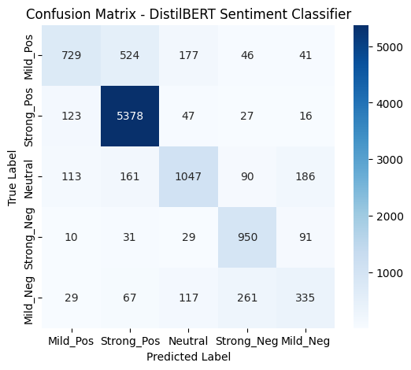

```python
#  Compute Confusion Matrix
cm = confusion_matrix(all_labels, all_preds)

#  Plot Confusion Matrix
plt.figure(figsize=(6, 5))
sns.heatmap(cm, annot=True, fmt="d", cmap="Blues", xticklabels=list(sentiment_mapping.values()), yticklabels=list(sentiment_mapping.values()))
plt.xlabel("Predicted Label")
plt.ylabel("True Label")
plt.title("Confusion Matrix - DistilBERT Sentiment Classifier")
plt.show()
```

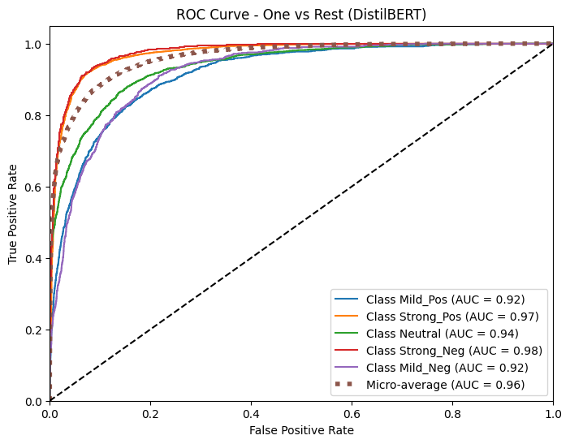

```python
#  Convert labels into one-hot encoding for AUC-ROC
y_test_bin = label_binarize(all_labels, classes=range(len(sentiment_mapping)))

#  Compute ROC curve and AUC for each class
fpr = dict()
tpr = dict()
roc_auc = dict()

for i in range(len(sentiment_mapping)):
    fpr[i], tpr[i], _ = roc_curve(y_test_bin[:, i], all_probs[:, i])
    roc_auc[i] = auc(fpr[i], tpr[i])

#  Compute micro-average ROC curve and AUC
fpr["micro"], tpr["micro"], _ = roc_curve(y_test_bin.ravel(), all_probs.ravel())
roc_auc["micro"] = auc(fpr["micro"], tpr["micro"])

#  Plot ROC Curves
plt.figure(figsize=(8, 6))
for i in range(len(sentiment_mapping)):
    plt.plot(fpr[i], tpr[i], label=f'Class {sentiment_mapping[i]} (AUC = {roc_auc[i]:.2f})')

plt.plot(fpr["micro"], tpr["micro"], label=f'Micro-average (AUC = {roc_auc["micro"]:.2f})', linestyle=':', linewidth=4)
plt.plot([0, 1], [0, 1], 'k--')  # Diagonal reference line
plt.xlim([0.0, 1.0])
plt.ylim([0.0, 1.05])
plt.xlabel('False Positive Rate')
plt.ylabel('True Positive Rate')
plt.title('ROC Curve - One vs Rest (DistilBERT)')
plt.legend(loc="lower right")
plt.show()
```